# Running HyADS for many sources

Lucas Henneman

2019-02-18

Here we provide an example workflow of how to run the HyADS model using `hyspdisp`. This vignette provides instruction on how to run the model and ensure the model runs completed. Subsequent vignettes will describe combining, manipulating, and interpreting results. **TO DECIDE: split into multiple vignettes, or keep as one?**

Begin by installing the package from Github. It is recommended to update all packages when prompted (expecially `SplitR`).

```r
devtools::install_github("lhenneman/hyspdisp@dev2")
library( hyspdisp)
```

## Getting started - downloading important files

Several files are required to run the functions in `hyspdisp`. This section presents procedures to download these.

#### ZIP code-ZCTA crosswalk file

The ZIP code linkage procedure requires a ZCTA-to-ZIP code Crosswalk file. ZCTAs are not exact geographic matches to ZIP codes, and multiple groups compile and maintain Crosswalk files. One example is the Crosswalk mainted by UDS Mapper. It can be retrieved and its names changed for consistency with `hyspdisp` functions with the following commands:

```r
library( openxlsx)
crosswalkin <- data.table( read.xlsx( xlsxFile =
                                        "https://www.udsmapper.org/docs/zip_to_zcta_2017.xlsx"))
setnames( crosswalkin,
          old = "ZIP_CODE",
          new = "ZIP")
```

#### Census population of Zip Code Tabulation Areas

While not necessary for the HYSPLIT model or processing of its outputs, population-weighted exposure metrics allow for direct comparisons between power plants. In anticipation of this, we load census data packaged by [American Fact Finder](https://factfinder.census.gov/bkmk/table/1.0/en/ACS/17_5YR/B01003/0100000US.86000) and merge it with the crosswalk data. The variable `ZCTA` must first be added from the included `Id2` variable before merging.

```r
data( ZCTApop2017)
ZCTApop2017[, ZCTA := formatC( Id2, format = 'd', flag = '0', width = 5)]
crosswalkin <- merge( ZCTApop2017, crosswalkin,
                      by = 'ZCTA')
```

#### ZCTA shapefile

Equally important is the ZCTA shapefile. These are available from multiple locations, including the [US census website](http://www2.census.gov/geo/tiger/GENZ2017/shp/cb_2017_us_zcta510_500k.zip). Code below downloads the file from the FTP site, which is more stable but slower. A third alternative (not shown) is to use the `tigris` r library. Download the file, unzip it, and read in the shapefile (here I’ve unzipped it to a directory in my Desktop). Loading the file may take a few moments.

```r
# Define the storage directory, create it if it does not exist
zcta_dir <- file.path('~', 'Desktop', 'run_hyspdisp', 'zcta_500k')
zcta_file <- file.path( zcta_dir, 'cb_2017_us_zcta510_500k.zip')
dir.create( zcta_dir,
            recursive = T,
            showWarnings = F)

# Download the file if it is not present
zcta_file_url <- 'ftp://ftp2.census.gov/geo/tiger/GENZ2017/shp/cb_2017_us_zcta510_500k.zip'
if( !file.exists( zcta_file)){
  download.file( url = zcta_file_url,
                 destfile = zcta_file)
  unzip( zcta_file, exdir = zcta_dir)
}

# Load the ZCTA shapefile using the shapefile command
zcta_shapefile <- file.path( zcta_dir, 'cb_2017_us_zcta510_500k.shp')
zcta <- shapefile( x = zcta_shapefile)
```

It is recommended to transform the ZCTA shapefile to a known projection to maintain consistency throughout the allocation process. Lat-lon projections are preferred, such as the [North American Albers Equal Area Conic](https://epsg.io/102008):

```r
p4s <- "+proj=aea +lat_1=20 +lat_2=60 +lat_0=40 +lon_0=-96 +x_0=0 +y_0=0 +ellps=GRS80 +datum=NAD83 +units=m"
zcta.trans <- spTransform( x = zcta,
                           CRSobj = p4s)
```

#### Monthly global planetary boundary layer

The final input file is the monthly mean boundary layer heights. For years up to and including 2012, these are available in a single file from [NOAA’s Earth System Research Library](https://www.esrl.noaa.gov/psd/data/gridded/data.20thC_ReanV2.monolevel.mm.html). For years 2013 and later (and available for years 2008 and on), you may use the [NCAR/UCAR data archive](https://rda.ucar.edu/thredds/catalog/files/e/ds630.1/e5.mnth.mean.an.sfc/catalog.html). The NCAR/UCAR annual files must be downloaded one by one. Below I’ve included examples for how to download the two types of files if they are not already in the file path.

```r
# Define a directory, create it if it does not exist
hpbl_dir <- file.path('~', 'Desktop', 'run_hyspdisp', 'hpbl')
dir.create( hpbl_dir,
            recursive = T,
            showWarnings = F)

# Download the PBL file from NOAA for years up to and including
hpbl_file_NOAA <- file.path( hpbl_dir, 'hpbl.mon.mean.nc')
url_NOAA <- "ftp://ftp.cdc.noaa.gov/Datasets/20thC_ReanV2/Monthlies/gaussian/monolevel/hpbl.mon.mean.nc"
if( !file.exists( hpbl_file_NOAA))
  download.file( url = url_NOAA,
                 destfile = hpbl_file_NOAA)

# Download the PBL file from NCAR for 2013
hpbl_file_NCAR2013 <- file.path( hpbl_dir, 'hpbl.mon.mean.nc_2013.grb')
url_NCAR <- "https://rda.ucar.edu/thredds/catalog/files/e/ds630.1/e5.mnth.mean.an.sfc/2013/catalog.html?dataset=files/e/ds630.1/e5.mnth.mean.an.sfc/2013/e5.mnth.mean.an.sfc.128_159_blh.regn320sc.2013010100_2013120100.grb"
if( !file.exists( hpbl_file_NCAR2013))
  download.file( url = url_NCAR,
                 destfile = hpbl_file_NCAR2013)
```

Both files are read in using the brick command, and rotated to match the lat-lon projection applied above. Before reading in, it is necessary to set the system time zone to UTC so that the dates are formatted correctly in the raster files. For the NCAR boundary layer files, it is not neccesary to set the `varname` argument in the `brick` function.

```r
Sys.setenv(TZ='UTC')
hpbl_rasterin <- brick( x = hpbl_file_NOAA,
                                varname = 'hpbl' )
```

## Setting up the inputs

Functions in `hyspdisp` require specific inputs. Their setups are detailed in this section.

#### Selecting units

Many of the units in the provided datasets do not have stack height data. In these cases, it is suggested in [Henneman et al. (2019)](https://www.sciencedirect.com/science/article/pii/S1352231019300731) to fill with the average stack height of all units.

```r
data( units2005)
units2005 <- data.table( units2005)[, V1 := NULL]
units.run <- units2005[ order( -SOx)][1:2]
units.run
```

| ID | Latitude | Longitude | SOx | CO2 | NOx | Height | Diam | Velocity | Temp | uID |
| --- | --- | --- | --- | --- | --- | --- | --- | --- | --- | --- |
| 3149-1 | 41.0714 | -76.6672 | 240250.9 | 18188647 | 22388.27 | 182.8800 | 6.0960 | 88.3920 | 300.9050 | 3149.1 |
| 3136-1 | 40.6604 | -79.3411 | 183555.8 | 13322458 | 13787.34 | 171.6024 | 10.3632 | 38.7096 | 283.6983 | 3136.1 |

#### Designate directories for storing output files

`hyspdisp` creates multiple file types that store information important in interpreting the results. It is recommended to define the locations beforehand so that you:

- can access the files later
- can ensure there is enough storage space available

In general, `hyspdisp` functions will create the directories if they do not already exist. If they are not defined, they will be created in the working directory. The following directories, as referenced in the functions below in this document, will contain:

- `proc_dir`: the overarching directory containing each of the subdirectories, and the working directory for HYSPLIT
- `hysraw_dir`: raw hyspdisp output (one file for each emissions event)
- `ziplink_dir`: files containing ZIP code linkages
- `meteo_dir`: (reanalysis) meteorology files
- `rdata_dir`: RData files containing HyADS source-receptor matrices

```r
## proc_dir defines where runs happen and output is saved
## up_dir is where input data is saved (upper file structure)
proc_dir <- file.path( '~', 'Desktop', 'run_hyspdisp')
hysraw_dir <- file.path( proc_dir, 'output_hysplit')
ziplink_dir <- file.path( proc_dir, 'output_ziplinks')
meteo_dir <- file.path( proc_dir, 'meteo')
rdata_dir <- file.path( proc_dir, 'output_rdata')
exposure_dir <- file.path( proc_dir, 'exposure_data')
```

#### Download reanalysis meteorology files

```r
metfiles.vignette <- c( 'RP200412.gbl',
                        'RP200501.gbl',
                        'RP200502.gbl',
                        'RP200503.gbl',
                        'RP200504.gbl',
                        'RP200505.gbl',
                        'RP200506.gbl',
                        'RP200507.gbl')
dir.create( meteo_dir,
            recursive = T,
            showWarnings = F)
metfiles.vignette <- metfiles.vignette[!(metfiles.vignette %in% list.files(meteo_dir))]
if( length( metfiles.vignette) > 0)
    get_met_reanalysis(files = metfiles.vignette,
                       path_met_files = meteo_dir)
```

#### Define time periods to be run

```r
## combine dates and hours
input_refs <- define_inputs( units = units.run,
                             startday = '2005-01-01',
                             endday = '2005-06-30')

names( input_refs)
```

| x |
| --- |
| ID |
| start_hour |
| start_day |
| duration_emiss_hours |
| duration_run_hours |
| Latitude |
| Longitude |
| SOx |
| CO2 |
| NOx |
| Height |
| Diam |
| Velocity |
| Temp |
| uID |

## Run hyspdisp worker functions

The following examples show how to run a small subset (chosen to provide workable examples on a laptop) of emissions events, link to ZIP codes, and plot the results.

#### Run HYSPLIT

The `hyspdisp_fac_model_parallel` function runs HYSPLIT for each emissions event described by the rows of the `run_ref_tab`. Inputs defined above, including the projected ZCTA shapefile (`zcta.trans`), the ZIP-ZCTA crosswalk (`crosswalkin`), the planetary boundary layer raster (`hpbl_rasterin`), and working directories are necessary in the function call. With `link2zip = T` you can link dispersion patterns from individual emissions events to ZIP codes; this, however, somewhat violates the spirit of HyADS, since the large number of emissions events is used as a check on some other uncertainties introduced by the simplifying assumptions.

Here it’s run for a sample of twenty (`run_sample`) rows of the `input_refs` table. The results will be saved in the `hysraw_dir`. `mc.cores` is an option in the mcapply function that controls the number of cores should be used. The output describes where the files are saved, or the reasons they were not run.

**If you get an error running HYSPLIT, it is likely because the meteorology files did not download correctly. Check your `meteo_dir` to ensure all files are present and at least 100MB in size.**

```r
library(parallel)
run_sample <- round(seq( 1, dim( input_refs)[1], length.out = 20))
hysp_raw <- mclapply( X = run_sample,
                      FUN = hyspdisp_fac_model_parallel,
                      run_ref_tab = input_refs,
                      zcta2 = zcta.trans,
                      crosswalk = crosswalkin,
                      hpbl_raster = hpbl_rasterin,
                      prc_dir = proc_dir,
                      hyo_dir = hysraw_dir,
                      met_dir = meteo_dir,
                      mc.cores = 6)
hysp_raw[1]
```

| out |
| --- |
| Partial trimmed parcel locations (below height 0 and the highest PBL height) already exist at /Users/luh919/Desktop/run_hyspdisp/output_hysplit/hyspdisp_3136-1_2005-01-01_00.csv |
| ZIP code parcel counts not called for or already exist at ~/Desktop/run_hyspdisp/zip_counts/ziplinks_3136-1_2005-01-01_00.csv |

#### Link results to ZIP codes

Most current implementations of HyADS, instead of linking dispersion patterns from individual emissions events, link the patterns by month. With the `hysdisp_zip_link` function, users can link all air parcels to ZIP codes by month for an individual unit. Here, we define the variables `yearmons` with combinations of years and months. `hysdisp_zip_link` reads in all the relevant files (i.e., those that correspond to the provided `month_YYYYMM` and `unit`) produced by the `hyspdisp_fac_model_parallel` function and saved to the `hyo_dir`, then links them to ZIP codes. The result is data.table of ZIP codes and relative contributions `N`, and an identical `.csv` file is saved to the `zpc_dir`. `N` is not weighted by the `unit`’s emissions. `hyspdisp_zip_link` is parallelizable for different months using `mclapply` or similar, and is run for a single unit at a time (we define the `unit` as the each unit in `unit.run`.)

```r
yearmons <- paste0( 2005, 1:12)
linked_zips1 <- mclapply( yearmons,
                          hyspdisp_zip_link,
                          unit = units.run[1],
                          hpbl_raster = hpbl_rasterin,
                          zcta2 = zcta.trans,
                          crosswalk = crosswalkin,
                          prc_dir = proc_dir,
                          zpc_dir = ziplink_dir,
                          hyo_dir = hysraw_dir,
                          mc.cores = 6)

linked_zips2 <- mclapply( yearmons,
                          hyspdisp_zip_link,
                          unit = units.run[2],
                          hpbl_raster = hpbl_rasterin,
                          zcta2 = zcta.trans,
                          crosswalk = crosswalkin,
                          prc_dir = proc_dir,
                          zpc_dir = ziplink_dir,
                          hyo_dir = hysraw_dir,
                          mc.cores = 6)
```

#### Plot the results

At this point, it makes sense to take a look at the results to see which ZIP codes are impacted by emissions from the facility whose impacts we just modeled. To acheive this, we can use the `plot_hyspdisp` function, which takes as input a data.table (or data.frame) linked to simple features ZIP code data. We can use the `st_read` function from the `sf` package to read in the same ZCTA shapefile we used to link the HYSPLIT output to ZIP codes. Next, we merge the `sf` ZIP code object to both the crosswalk file and the `linked_zips` object created above, then feed the merged dataset to the `plot_hyspdisp` function, which returns a ggplot object.

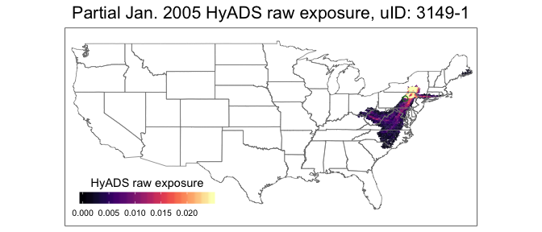

```r
library(sf)
library(viridis)
library(ggplot2)
library(scales)

zips.sf <- st_read(zcta_shapefile)
setnames( zips.sf, 'ZCTA5CE10', 'ZCTA')

zips_crosswalk.sf <- merge( zips.sf,
                            crosswalkin,
                            by = "ZCTA", all = F, allow.cartesian = TRUE)

zip_dataset_sf <- data.table( merge( zips_crosswalk.sf,
                                     linked_zips1[[1]],
                                     by = c('ZIP'), all.y = T))

ziplink_plot <- plot_hyspdisp(hyspdisp_out.sf = zip_dataset_sf,
                              metric = 'N',
                              plot.title = paste('Partial Jan. 2005 HyADS raw exposure, uID:',
                                                 units.run[1, ID]),
                              legend.title = 'HyADS raw exposure',
                              facility.loc = data.table( x = units.run[1, Longitude],
                                                         y = units.run[1, Latitude]))
ziplink_plot
```

#### Combine all results into RData file

So far, we have run two worker functions important to the implementation of HyADS:

- `hyspdisp_fac_model_parallel`: ran HYSPLIT for unit-date-time emission event combinations and saved an output file for each
- `hyspdisp_zip_link`: gathered output files from `hyspdisp_fac_model_parallel`, grouped them by month and unit, and linked the HYSPLIT parcel locations contained in the files to ZIP codes.

In practice, these two worker functions may need to be implemented in parallel R sessions on a cluster to improve efficiency. It helps for future analyses to gather the relevant monthly files and save them as a single RData file. This is made possible by `combine_monthly_ziplinks`, which saves an RData file of annual monthly results to the `rda_dir`.

```r
combined_ziplinks <- combine_monthly_ziplinks( month_YYYYMMs = yearmons,
                                               zpc_dir = ziplink_dir,
                                               rda_dir = rdata_dir)
names( combined_ziplinks)
```

| x |
| --- |
| MAP1.2005 |
| MAP2.2005 |
| MAP3.2005 |
| MAP4.2005 |
| MAP5.2005 |
| MAP6.2005 |
| MAP7.2005 |

## Calculate and extract useful information from the results

Up until now, this vignette has focused on producing unweighted HyADS results. Once the procedure above has been followed, it is farily straightforward to weight the unweighted HyADS results by emissions (or other quantity) and aggregate the results by source, receptor, and/or time period.

#### Load power plant emissions data

The `hyspdisp` package include monthly power plant emissions, load, and heat input data, accessible using the following command:

```r
data( PP.units.monthly1995_2017)
```

#### Weight the results by emissions

The `calc_zip_exposure` function takes as input the .RData file created by `combined_ziplinks` and monthly power plant emissions. The user can select the hyspdisp year (`year.H`), the emissions year (`year.E`), the weighting pollutant (although it does not necessarily have to be a pollutant), the source aggregation (`source.agg` can be designated ‘total’, ‘facility’, or ‘unit’), the time aggregation (`time.agg` can be set to ‘month’ or year’). Results are saved to the `exp_dir` and returned, but `return.monthly.data` must be set to true to return data when `time.agg = 'month'` (the default was set to save working memory space).

Here, we first calculate the annual HyADS emissions weighted exposure for all emissions modeled above and plot the results.

```r
zip_exp_ann <- calc_zip_exposure(rda_file = "~/Desktop/run_hyspdisp/output_rdata/hyads_unwgted_2005.RData",
                                 units.mo = PP.units.monthly1995_2017,
                                 year.E = 2005,
                                 year.H = 2005,
                                 pollutant = 'SO2.tons',
                                 source.agg = 'total',
                                 time.agg = 'year',
                                 exp_dir = exposure_dir)
```

```
#> [1] "Calculating ZIP code exposures for HYSPLIT year 2005 and emissions year 2005!"
```

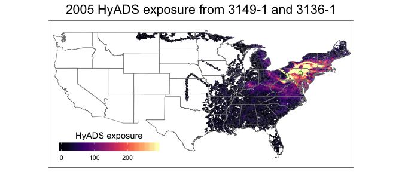

```r
zip_exp_ann_sf <- data.table( merge( zips_crosswalk.sf,
                                     zip_exp_ann,
                                     by = c('ZIP'), all.y = T))

zip_exp_ann_plot <- plot_hyspdisp(hyspdisp_out.sf = zip_exp_ann_sf,
                              metric = 'hyads',
                              plot.title = paste('2005 HyADS exposure from',
                                                 units.run[1, ID], 'and', units.run[2, ID]),
                              legend.title = 'HyADS exposure',
                              facility.loc = data.table( x = units.run[, Longitude],
                                                         y = units.run[, Latitude]))

zip_exp_ann_plot
```

#### Plot unit-specific impacts over time

Next, we calculate the monthly emissions weighted HyADS exposure (again, only from the select few runs we initiated above). Code below plots the monthly exposure contributions of the two units in ZIP code 21613, which is located in Maryland. Note that this ZIP code was not impacted by the facilities in all the modeled months in 2005.

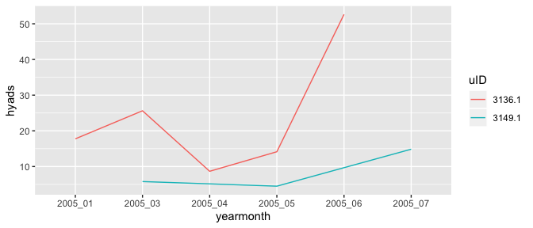

```r
zip_exp_unit_mo <- calc_zip_exposure(rda_file = "~/Desktop/run_hyspdisp/output_rdata/hyads_unwgted_2005.RData",
                                     units.mo = PP.units.monthly1995_2017,
                                     year.E = 2005,
                                     year.H = 2005,
                                     pollutant = 'SO2.tons',
                                     source.agg = 'unit',
                                     time.agg = 'month',
                                     exp_dir = exposure_dir,
                                     return.monthly.data = T)

zip_exp_unit_mo[, uID := as( uID, 'character')]
qplot( x = yearmonth,
       y = hyads,
       group = uID,
       color = uID,
       data = zip_exp_unit_mo[ZIP == 21613],
       geom = 'line')
```

#### Rank facilities

In the examples provided above, we selected two coal units *a priori* to analyze. However, a benefit of HyADS over more complex models is the ability to easily rank-order emissions sources to identify the sources that contribute the most to exposure in a given area. The following code snippet applies the `calc_zip_exposure` function to calculate annual impacts by unit (here, only the two units selected above), then rank-orders their population-weighted exposures on Pennsylvania using the `rankfacs_by_popwgt_location` function. In this function, the input ZIP-code linkage dataset is defined by `link.dt = zip_exp_ann_unit`; the `crosswalkin` file employed above is used again, this time including a column named `year` to ensure the appropriate population-weighting is used; the `census.pop.name` defines the population column in `crosswalkin` (recall we linked ACS ZIP-code populations with the crosswalk file above); the `rank.by` column defines the variables in `zip_exp_ann_unit` to rank by—it is possible to define multiple values (e.g., `rank.by = c( 'hyads', 'SOx')`) to rank by multiple ranking variables if they are available; finally, `state.value`, `city.value`, and `zip.value` can be defined to limit the area of influence (here, we only rank these units’ influences on Pennsylvania with `state.value = 'PA'`).

```r
zip_exp_ann_unit <- calc_zip_exposure(year.E = 2005,
                                      year.H = 2005,
                                      pollutant = 'SO2.tons',
                                      rda_file = file.path( rdata_dir,
                                                            "hyads_unwgted_2005.RData"),
                                      exp_dir = exposure_dir,
                                      units.mo = PP.units.monthly1995_2017,
                                      source.agg = 'unit',
                                      time.agg = 'year')


crosswalkin2005 <- copy( crosswalkin)[, year := 2005]
zip_exp_ann_unit[, year := 2005]

unitRanks2005 <- rankfacs_by_popwgt_location( link.dt = zip_exp_ann_unit,
                                              census.dt = crosswalkin2005,
                                              census.pop.name = 'Estimate; Total',
                                              rank.by = c( 'hyads'),
                                              state.value = 'PA')
unitRanks2005
```

| uID | year | hyads.py.sum | hyads.rank |
| --- | --- | --- | --- |
| 3136.1 | 2005 | 1908264916 | 2 |
| 3149.1 | 2005 | 2054720409 | 1 |

#### Plot ranked facilities

Finally, we can make two plots: one that shows the total 2005 emissions from each of the units in 2005, and one that shows the total population-weighted exposure from these units. We start by linking `unitRanks2005` back with the unit location and emissions information, then execute the `plot_ranked_facs` command twice, once to size the facility units by emissions, and a second to size by `hyads.py.sum`, the metric of population-weighted influence calculated by `rankfacs_by_popwgt_location`.

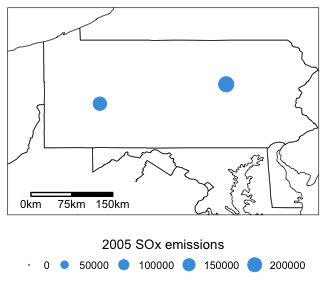

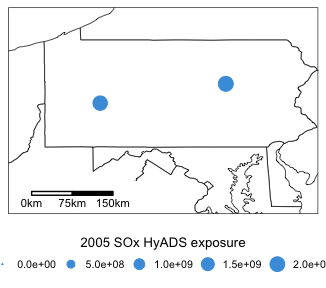

```r
unitRanks2005 <- merge( unitRanks2005, units2005, by = 'uID')
SOx_emiss_plot <- plot_ranked_facs( ranks.dt = unitRanks2005,
                                    size.var = 'SOx',
                                    size.name = "2005 SOx emissions",
                                    plot.title = NULL,
                                    xlims = c( -81, -75),
                                    ylims = c( 38.5, 42.5),
                                    dist.scalebar = 150)

SOx_emsposure_plot <- plot_ranked_facs( ranks.dt = unitRanks2005,
                                        size.var = 'hyads.py.sum',
                                        size.name = "2005 SOx HyADS exposure",
                                        plot.title = NULL,
                                        xlims = SOx_emiss_plot$latlonrange$xlim,
                                        ylims = SOx_emiss_plot$latlonrange$ylim,
                                        dist.scalebar = 150)
```